# Bayou Workshop Notebook

# Customized/Allometric models

What if there is a known (or unknown) relationship between the trait of interest and another predictor variable? For example, we may be interested in a relationship between trait known to vary with body size, but consider the possibility that the relationship with body size itself varies over macroevolutionary time. Here, instead of having a single optimum that changes upon a regime shift, it is possible to have both the slope and intercept of the relationship change at once. bayou v2.0 allows you to include these additional predictors and test for shifts in the scaling between a trait and its predictors.

Let’s simulate a dataset where the slope and intercept shift at different points in the tree. We’re going to use the same shift locations as before, but add in a covariate with body size that changes in different parts of the tree. We also need to simulate the predictor data, in this case, let’s use Brownian Motion.

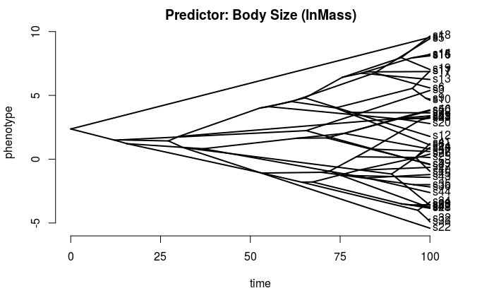

```r
set.seed(1)
tree <- sim.bdtree(b=1, d=0, stop="taxa", n=50, seed=1)
tree$edge.length <- tree$edge.length/max(branching.times(tree))*100
tree <- reorder(tree, "postorder")
truepars <- list(alpha = 0.5, sig2 = 0.05,
                 k = 3, ntheta = 4,
                 beta_lnMass = c(0.75, 0.6, 0.9, 0.67),
                 theta = c(-1, 1.25, 0.5, 0),
                 sb = c(94, 71, 50),
                 loc = c(0, 0, 0),
                 t2 = 2:4)
pred <- cbind("lnMass" = sim.char(tree, 0.2, model="BM", root=3)[,,1])
phytools::phenogram(tree, setNames(pred[,1], tree$tip.label), spread.labels=FALSE, main="Predictor: Body Size (lnMass)")
```

```
[1] "Using mapped regimes from parameter list"
```

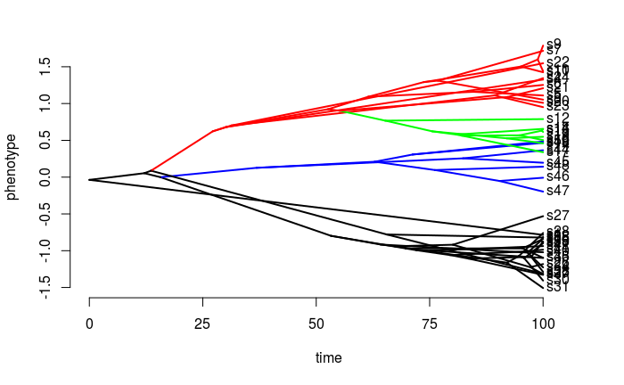

```r
dumdat <- dataSim(truepars, "OU", tree)$dat
```

```
[1] "Using mapped regimes from parameter list"
```

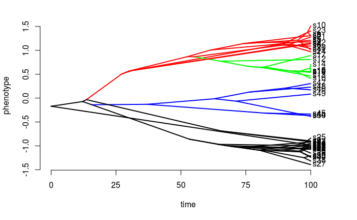

```r
cache <- bayou:::.prepare.ou.univariate(tree, dumdat, SE=0, pred=pred)
W <- bayou:::C_weightmatrix(cache, truepars)
set.seed(1)
dat2 <- dataSim(truepars, tree, model="OU")$dat + truepars$beta_lnMass[bayou:::.tipregime(truepars, tree)] * pred[,1]
```

```
[1] "Using mapped regimes from parameter list"
```

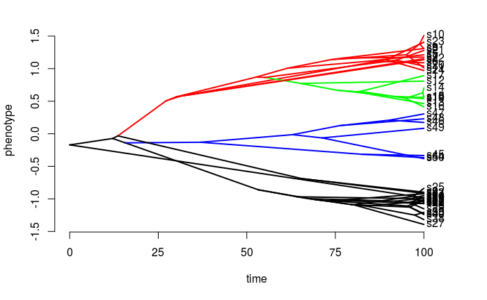

```r
set.seed(1)
dat <- dataSim(truepars, tree, model="OU")$dat + W$W%*%truepars$beta_lnMass * pred[,1]
```

```
[1] "Using mapped regimes from parameter list"
```

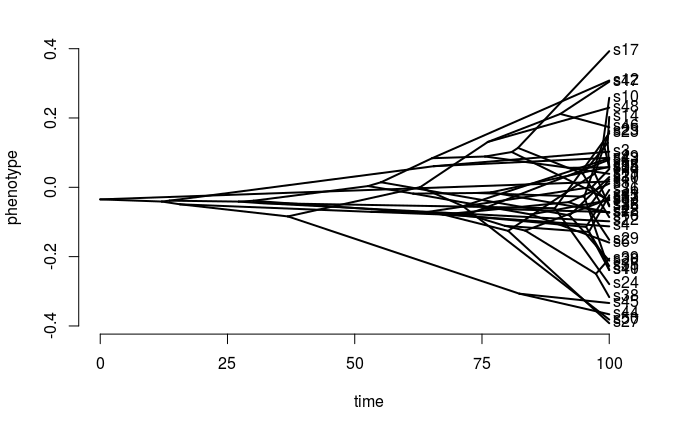

```r
dat <- setNames(dat[,1], cache$phy$tip.label)
set.seed(1)
trueparsPGLS <- list(alpha=truepars$alpha, sig2=truepars$sig2, k=0, ntheta=1, theta=0, sb=numeric(0), loc=numeric(0), t2=numeric(0))
dat3 <- dataSim(trueparsPGLS, tree, model="OU")$dat
```

```r
dat3 <-truepars$theta[bayou:::.tipregime(truepars, tree)] + truepars$beta_lnMass[bayou:::.tipregime(truepars, tree)] * pred[,1] + dat3
```

But our old visualization doesn’t give the whole picture, because the trait covaries with body size:

```r
par(mfrow=c(1,2))
## Plot the regime locations
plotRegimes(pars2simmap(truepars,tree)$tr,  col=pars2simmap(truepars,tree)$col)
## Plot the allometry
plot(pred[,1], dat, pch=21, bg=bayou:::.tipregime(truepars, tree), xlab="lnMass", "ylab"="Trait")
```

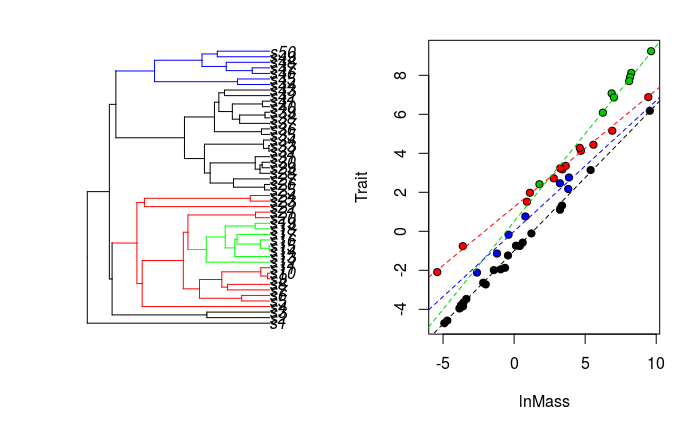

```r
## Add the regression lines
dum <- lapply(1:truepars$ntheta, function(x) abline(truepars$theta[x], truepars$beta_lnMass[x],  lty=2, col=x))
```

```r
plot(pred[,1], dat2, pch=22, bg=bayou:::.tipregime(truepars, tree), xlab="lnMass", "ylab"="Trait")
dum <- lapply(1:truepars$ntheta, function(x) abline(truepars$theta[x], truepars$beta_lnMass[x],  lty=2, col=x))
```

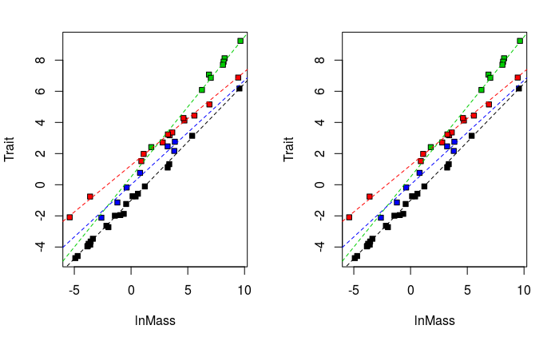

```r
plot(pred[,1], dat3, pch=22, bg=bayou:::.tipregime(truepars, tree), xlab="lnMass", "ylab"="Trait")
dum <- lapply(1:truepars$ntheta, function(x) abline(truepars$theta[x], truepars$beta_lnMass[x],  lty=2, col=x))
```

We are going to test 3 models in this analysis: Global intercepts & slopes (11), Separate intercepts & global slope (N1), and separate intercepts & slopes (NN). However, we’re going to have to build these models to run them (they aren’t built into **bayou**). As a convention, we’re going to name our regression coefficients (other than the familiar intercept, *theta*) “beta_” followed by the predictor name (e.g. *beta_lnMass*). Here we imagine we have some fairly informative prior belief about what the allometry with body mass should be (normal distribution around 0.7).

```r
prior.11 <- make.prior(tree, plot.prior = FALSE,
                       dists=list(dalpha="dhalfcauchy", dsig2="dhalfcauchy", dbeta_lnMass="dnorm",
                                  dsb="fixed", dk="fixed", dtheta="dnorm"),
                       param=list(dalpha=list(scale=0.1), dsig2=list(scale=0.1),
                                  dbeta_lnMass=list(mean=0.7, sd=0.2),
                                  dtheta=list(mean=0, sd=1.5)),
                       fixed=list(k=0, sb=numeric(0))
)
prior.N1 <- make.prior(tree, plot.prior = FALSE,
                       dists=list(dalpha="dhalfcauchy", dsig2="dhalfcauchy", dbeta_lnMass="dnorm",
                                  dsb="dsb", dk="cdpois", dtheta="dnorm"),
                       param=list(dbeta_lnMass=list(mean=0.7, sd=0.2),
                                  dk=list(lambda=10, kmax=50),
                                  dtheta=list(mean=0, sd=1.5))
)
prior.NN <- make.prior(tree, plot.prior = FALSE,
                       dists=list(dalpha="dhalfcauchy", dsig2="dhalfcauchy", dbeta_lnMass="dnorm",
                                  dsb="dsb", dk="cdpois", dtheta="dnorm"),
                       param=list(dalpha=list(scale=0.1), dsig2=list(scale=0.1),
                                  dbeta_lnMass=list(mean=0.7, sd=0.2),
                                  dk=list(lambda=10, kmax=50),
                                  dtheta=list(mean=0, sd=1.5))
)
```

```r
D11 = list(alpha=2, sig2=2, beta_lnMass=0.1, k=1, theta=0.5, slide=1)
DN1 = list(alpha=2, sig2=2, beta_lnMass=0.1, k=1, theta=2, slide=1)
DNN = list(alpha=2, sig2=2, beta_lnMass=0.3, k=c(1,1), theta=2, slide=1)
```

Now we use the function *makeBayouModel* to create a **bayou** model object that specifies all the components **bayou** needs to drop a new model into the analysis. Note that if you are interested in developing in **bayou** these are intended to be easy to make for customized models and there is a lot more possible than what is shown here. Note that each model only differs in the number of reversible-jump parameters (0, 1, and 2), the prior and the tuning parameters. By default, the starting regime map is plotted.

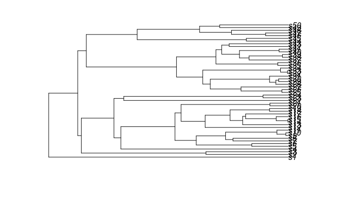

```r
MEvar <- 0
dat <- dat3
set.seed(1)
model.11 <- makeBayouModel(dat ~ lnMass, rjpars = c(),
                           tree=tree, dat=dat, pred=pred, SE=MEvar, prior=prior.11, D=D11, slopechange="fullPGLS")
```

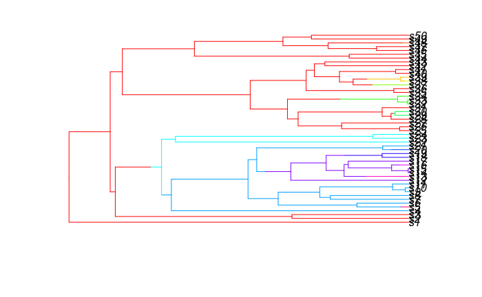

```r
model.N1 <- makeBayouModel(dat ~ lnMass, rjpars = c("theta"),
                           tree=tree, dat=dat, pred=pred, SE=MEvar, prior=prior.N1, D=DN1, slopechange="fullPGLS")
```

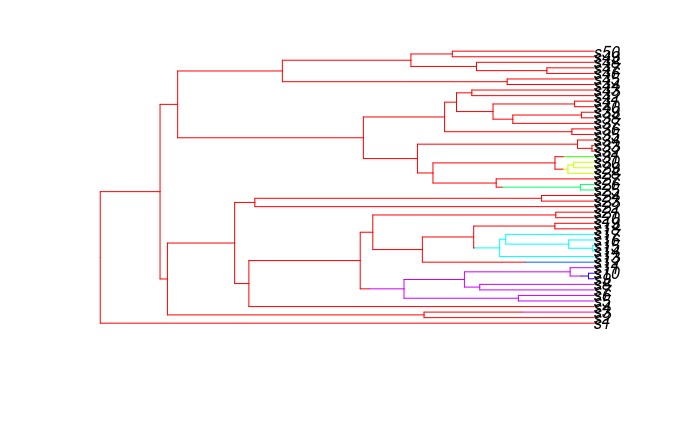

```r
model.NN <- makeBayouModel(dat ~ lnMass, rjpars = c("theta", "lnMass"),
                           tree=tree, dat=dat, pred=pred, SE=MEvar, prior=prior.NN, D=DNN, slopechange="fullPGLS")
```

We can now drop these model object into the analysis, along with the generated starting values (replacing the out of the box options of “OU”, “OUrepar” and “QG”).

```r
## Make MCMC objects:
mcmc.11 <- bayou.makeMCMC(tree, dat, pred=pred, SE=MEvar, model=model.11$model, prior=prior.11, startpar=model.11$startpar, new.dir="../output/AllometryTest/", outname="model11_r006", plot.freq=NULL)
mcmc.N1 <- bayou.makeMCMC(tree, dat, pred=pred, SE=MEvar, model=model.N1$model, prior=prior.N1, startpar=model.N1$startpar, new.dir="../output/AllometryTest/", outname="modelN1_r006", plot.freq=NULL)
```

```
'../output/AllometryTest' already exists
```

```r
mcmc.NN <- bayou.makeMCMC(tree, dat, pred=pred, SE=MEvar, model=model.NN$model, prior=prior.NN, startpar=model.NN$startpar, new.dir="../output/AllometryTest/", outname="modelNN_r006", plot.freq=NULL)
```

```
'../output/AllometryTest' already exists
```

Run the models and load them in.

```r
set.seed(1)
mcmc.11$run(10000)
```

```
gen     lnL     prior   alpha   sig2    beta_ln rtheta  k       .alpha  .beta_l .sig2   .theta
1000    -30.75  3.06    0.00    0.01    0.72    -0.03   0       0.77    0.63    0.35    0.85
2000    -33.86  3.01    0.01    0.01    0.75    -0.19   0       0.74    0.63    0.36    0.85
3000    -32.19  3.03    0.01    0.01    0.66    -0.12   0       0.76    0.67    0.37    0.86
4000    -32.14  3.03    0.00    0.01    0.70    0.36    0       0.76    0.66    0.36    0.86
5000    -32.09  3.03    0.00    0.01    0.74    -0.20   0       0.75    0.67    0.34    0.86
6000    -33.05  3.03    0.00    0.01    0.68    -0.25   0       0.76    0.66    0.33    0.86
7000    -31.52  3.02    0.00    0.01    0.65    -0.12   0       0.76    0.66    0.34    0.86
8000    -32.02  3.04    0.01    0.01    0.68    0.20    0       0.76    0.66    0.32    0.86
9000    -34.58  3.02    0.01    0.01    0.74    0.10    0       0.76    0.67    0.33    0.86
10000   -31.98  3.05    0.01    0.01    0.68    0.10    0       0.76    0.67    0.32    0.86
```

```r
mcmc.N1$run(10000)
```

```
gen     lnL     prior   alpha   sig2    beta_ln rtheta  k       .alpha  .beta_l birth.k D0.slid D1.slid death.k .sig2   .theta  U0.slid U1.slid U2.slid
1000    -17.96  -55.56  17.90   4.74    0.70    -0.96   9       0.25    0.52    0.07    1.00    0.40    0.79    0.38    0.49    1.00    0.00    0.33
2000    -5.47   -47.27  34.75   4.29    0.67    -1.30   7       0.28    0.40    0.05    1.00    0.50    0.57    1.00    0.36    0.40    1.00    0.20    0.33
3000    -6.69   -64.28  375.32  48.61   0.67    -1.10   10      0.30    0.37    0.05    1.00    0.50    0.54    1.00    0.33    0.34    1.00    0.16    0.26
4000    -14.22  -42.31  100.17  22.79   0.70    -1.01   5       0.30    0.36    0.04    1.00    0.44    0.51    1.00    0.31    0.32    1.00    0.14    0.21
5000    -4.23   -50.30  171.76  26.01   0.69    -1.09   7       0.30    0.34    0.04    1.00    0.42    0.50    1.00    0.34    0.31    1.00    0.12    0.21
6000    -4.42   -46.93  219.43  26.80   0.66    -1.27   6       0.31    0.32    0.04    1.00    0.37    0.47    1.00    0.36    0.30    1.00    0.13    0.20
7000    -3.89   -58.92  64.43   10.81   0.64    -1.33   10      0.30    0.32    0.04    1.00    0.36    0.46    1.00    0.35    0.29    1.00    0.14    0.28
8000    -8.11   -53.87  9.72    1.18    0.70    -1.05   9       0.31    0.31    0.04    1.00    0.38    0.46    1.00    0.35    0.30    1.00    0.17    0.28
9000    7.18    -52.67  11.85   0.88    0.72    -1.11   9       0.31    0.30    0.04    1.00    0.40    0.46    1.00    0.36    0.29    1.00    0.18    0.29
10000   -1.01   -49.21  11.65   1.42    0.77    -0.98   8       0.31    0.30    0.04    1.00    0.43    0.43    1.00    0.36    0.28    1.00    0.20    0.28
```

```r
mcmc.NN$run(10000)
```

```
gen     lnL     prior   alpha   sig2    beta_ln rtheta  k       .alpha  .beta_l birth.k D0.slid D1.slid death.k .sig2   .theta  U0.slid U1.slid U2.slid
1000    8.73    -30.06  0.44    0.05    0.78    -0.94   6       0.34    0.43    0.06    1.00    0.55    0.60    0.45    0.34    1.00    0.75    0.20
2000    13.91   -29.01  1.04    0.09    0.74    -1.09   5       0.34    0.37    0.03    1.00    0.53    0.39    0.39    0.27    1.00    0.50    0.12
3000    19.36   -25.75  1.57    0.07    0.75    -1.05   4       0.33    0.31    0.03    1.00    0.57    0.39    0.35    0.22    1.00    0.29    0.20
4000    26.69   -42.02  1.19    0.06    0.75    -1.04   8       0.32    0.32    0.03    1.00    0.52    0.37    0.35    0.20    1.00    0.28    0.24
5000    14.49   -40.14  3.32    0.22    0.76    -1.13   7       0.32    0.33    0.03    1.00    0.56    0.35    0.35    0.19    1.00    0.25    0.24
6000    22.25   -33.43  0.58    0.03    0.76    -1.10   7       0.33    0.34    0.02    1.00    0.51    0.36    0.34    0.19    1.00    0.23    0.23
7000    24.06   -35.46  0.41    0.02    0.75    -0.92   8       0.33    0.34    0.03    1.00    0.49    0.34    0.35    0.19    1.00    0.21    0.20
8000    19.17   -33.16  0.52    0.02    0.75    -0.86   7       0.34    0.34    0.02    1.00    0.50    0.31    0.36    0.18    1.00    0.18    0.19
9000    21.66   -30.69  0.15    0.01    0.76    -1.08   7       0.33    0.33    0.02    1.00    0.51    0.32    0.33    0.18    1.00    0.19    0.19
10000   18.12   -22.81  0.19    0.01    0.75    -1.08   4       0.34    0.33    0.02    1.00    0.52    0.33    0.33    0.18    1.00    0.18    0.19
```

```r
chain.11 <- set.burnin(mcmc.11$load(), 0.3)
chain.N1 <- set.burnin(mcmc.N1$load(), 0.3)
chain.NN <- set.burnin(mcmc.NN$load(), 0.3)
```

A particularly useful way to plot these is to use the *shiftSummaries* and *plotShiftSummaries* functions. Like other plotting functions, we define a posterior probability cutoff and only plot those shifts (*pp.cutoff*). Note that the global allometry (*11*), has no shifts and is not plotted here.

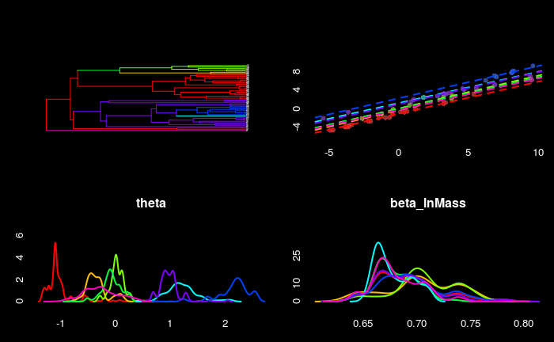

```r
shiftsumsN1 <- shiftSummaries(chain.N1, mcmc.N1, pp.cutoff=0.3, burnin=0.3)
shiftsumsNN <- shiftSummaries(chain.NN, mcmc.NN, pp.cutoff=0.3, burnin=0.3)
plotShiftSummaries(shiftsumsN1, lwd=2, single.plot=TRUE, label.pts=FALSE)
```

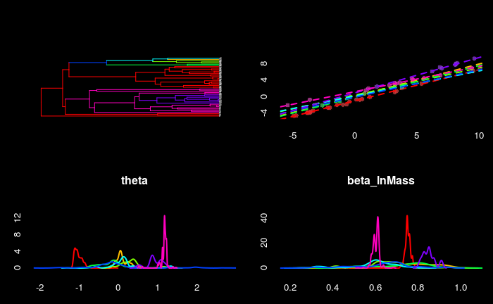

```r
plotShiftSummaries(shiftsumsNN, lwd=2, single.plot=TRUE, label.pts=FALSE)
```

As before, we can compare different models by estimating marginal likelihoods. Divide and conquer.

```r
registerDoParallel(cores=5)
Bk <- qbeta(seq(0,1, length.out=5), 0.3,1)
set.seed(1)
ss.11 <- mcmc.11$steppingstone(10000, chain.11, Bk, burnin=0.3, plot=FALSE)
ss.N1 <- mcmc.N1$steppingstone(10000, chain.N1, Bk, burnin=0.3, plot=FALSE)
ss.NN <- mcmc.NN$steppingstone(10000, chain.NN, Bk, burnin=0.3, plot=FALSE)
mlnL <- c("11"=ss.11$lnr, "N1"=ss.N1$lnr, "NN"=ss.NN$lnr)
mlnL
```

```
       11        N1        NN
-43.47956 -52.70670 -32.32900
```

# Concluding words

- **Caveat 1**: The reversible-jump analysis doesn’t always work. Sometimes it doesn’t converge in a reasonable amount of time, sometimes it doesn’t find anything interesting. It’s fairly prior sensitive to the number of shifts. Sometimes it’s hard to come up with reasonable priors.
  - Don’t put too much stock in the number of shifts recovered. Instead, consider the **number of highly supported shifts**. Consider magnitude. This means you have to understand the units of the parameters. If you get about 20 shifts in your posterior and your prior was about 20 shifts, this doesn’t mean you have strong support for 20 shifts. Often, no single branch will have high support, and the shifts will be of negligible magnitude. However, if 5/20 DO have high support, and are of high magnitude these are likely important features to understand in your data!
  - In general, we found it’s better to put higher priors on the number of shifts that fit models more complex than needed, than it is to put a lower prior on the number of shifts that keeps the fit from becoming as complex that as it needs to be. If the prior disallows the number of shifts it needs to explain the data, often the model will collapse to a BM like model. When this happens, the number of shifts and the value of theta doesn’t really matter anymore, they don’t affect anything in the model, and the model is unlikely to find the true posterior (even the *true* arrangement of shifts doesn’t really affect the likelihood when *alpha* is stuck in the land of Brownian Motion.) It can be useful to try many starting points, or even start with an overfitted model and let *bayou* drop shifts rather than add them.
  - Don’t be afraid to use informative priors. Even very weakly informative priors. For example, if you’re studying mammal body size, can you rule out animals larger than earth? Smaller than an atom? Your prior should reflect this! You’d be surprised how often priors we use, or estimates from ML optimizations, result in parameters in these ranges.
  - Think in terms of phylogenetic half-life and stationary variance. It’s more intuitive.
- **Caveat 2**: The reversible-jump approach is data snooping. Plus, it’s hard to summarize, it’s hard to conceptualize, and it’s complicated.
  - I like to take the following strategy in my analyses. I view the reversible-jump approach as an exploratory, natural history based approach for understanding the *major features* of my data. I want to know which groups are unique and doing something different because we don’t see in *phylogenetic time*, we see only extant species and our view of the evolutionary pattern is warped by the phylogeny. rjMCMC is a *tool to see the pattern of evolution through phylogenetic time*.
  - Once you identify the major features of your data, it’s reasonable to ask **why?** Compare different a priori or fixed hypotheses using Bayes Factors. Find the best one as you would normally in model selection. However, if that model fails to explain those *major features* of your data, you have more work to do to find a better model.
  - A useful approach is to compare a model with the shifts found in your reversible-jump analysis to a model without shifts, but with an explanatory predictor added. Essentially, you ask *is the data better explained by clade-level shifts (with many parameters) or a single or handful of predictor variables?* Can you *explain away* clade-level shifts with predictors? Can I *explain away* several clade-specific shifts to higher regimes in whales, pinnipeds and Sirenia by including the predictor *aquatic* into my analysis?
- **Caveat 3**: **bayou** is not the best OU tool for every situation. **bayou** is cool because it’s Bayesian. OU models are cool because they are supposed to represent biologically realistic processes of adaptation. So the parameters mean something biological. So the parameters have prior expectations. Also, **bayou** is useful for exploring and understanding your data. However:
  - Right now, **bayou** doesn’t fit OUwie-type models effectively. If you have questions about changing dynamics of regimes (changing *alpha* or *sig2*), such as a hypothesis that one clade is more constrained than another – use OUwie.
  - There can be identifiability issues with **bayou**. You can imagine that the a similar set of shifts can result in the same distribution of data. If multiple shifts occur on a branch, for example. Or if two shifts occur on neighboring branches. There are many configurations that can lead to identical or nearly identical likelihoods and mixing can be difficult. Run multiple chains. If they each get stuck with alternative, but similar configurations of shifts with poor mixing, you will know that identifiability is an issue. Likelihood-based tools such as **l1ou** have implemented approaches for dealing with this issue that hopefully will soon be implemented in **bayou** as well.
  - The packages **slouch** and **mvSLOUCH** implement a full suite of “evolutionarily-aware” regression approaches that are likely more better than the approaches I have outlined here. They don’t find shifts, you have to assume them, and the can be difficult to use…but in most cases the models are more evolutionarily reasonable. These are sorely underused packages. They solve a problem with PGLS that most people don’t even realize is there. In **bayou**’s simple allometric models, the value of a predictor (e.g. body size) immediately effects the trait. This is a lot like PGLS and reasonable if the two traits are mechanistically or developmentally linked (body mass automatically increases as you grow longer). But this isn’t true for a trait like *precipitation*. How much it rained this year isn’t going to be a perfect predictor of body mass, though body mass may respond to precipitation. But it doesn’t respond quickly. Instead, it responds to a moving average of precipitation. You can’t predict “optimal” body mass for a lineage from current conditions, you need the whole history of precipitation conditions to model where the optima was in the past, as well as today. This means you need to model the evolutionary history of precipitation for a lineage as well as the evolutionary history of body mass. You need **slouch** to do this. (Again, hopefully these models will soon be in **bayou** too)
  - **bayou** is not truly multivariate. Better packages for fitting multivariate OU models include **mvSLOUCH**, **mvMORPH** and **ouch**. This will also hopefully change in the future.